# Risk Factor Analysis

## Outcome Variable

**Outcome Variable:** stunted

## Predictor Variables

**Intervention Variable:** pers_wast

**Adjustment Set:**

unadjusted

## Stratifying Variables

The analysis was stratified on these variable(s):

- agecat
- studyid
- country

## Data Summary

| agecat | studyid | country | pers_wast | stunted | n_cell | n |
| --- | --- | --- | --- | --- | --- | --- |
| Birth | ki0047075b-MAL-ED | BANGLADESH | 0 | 0 | 203 | 255 |
| Birth | ki0047075b-MAL-ED | BANGLADESH | 0 | 1 | 43 | 255 |
| Birth | ki0047075b-MAL-ED | BANGLADESH | 1 | 0 | 7 | 255 |
| Birth | ki0047075b-MAL-ED | BANGLADESH | 1 | 1 | 2 | 255 |
| 6 months | ki0047075b-MAL-ED | BANGLADESH | 0 | 0 | 190 | 241 |
| 6 months | ki0047075b-MAL-ED | BANGLADESH | 0 | 1 | 44 | 241 |
| 6 months | ki0047075b-MAL-ED | BANGLADESH | 1 | 0 | 6 | 241 |
| 6 months | ki0047075b-MAL-ED | BANGLADESH | 1 | 1 | 1 | 241 |
| 24 months | ki0047075b-MAL-ED | BANGLADESH | 0 | 0 | 109 | 212 |
| 24 months | ki0047075b-MAL-ED | BANGLADESH | 0 | 1 | 97 | 212 |
| 24 months | ki0047075b-MAL-ED | BANGLADESH | 1 | 0 | 5 | 212 |
| 24 months | ki0047075b-MAL-ED | BANGLADESH | 1 | 1 | 1 | 212 |
| Birth | ki0047075b-MAL-ED | BRAZIL | 0 | 0 | 170 | 191 |
| Birth | ki0047075b-MAL-ED | BRAZIL | 0 | 1 | 21 | 191 |
| 6 months | ki0047075b-MAL-ED | BRAZIL | 0 | 0 | 202 | 209 |
| 6 months | ki0047075b-MAL-ED | BRAZIL | 0 | 1 | 6 | 209 |
| 6 months | ki0047075b-MAL-ED | BRAZIL | 1 | 0 | 1 | 209 |
| 6 months | ki0047075b-MAL-ED | BRAZIL | 1 | 1 | 0 | 209 |
| 24 months | ki0047075b-MAL-ED | BRAZIL | 0 | 0 | 162 | 169 |
| 24 months | ki0047075b-MAL-ED | BRAZIL | 0 | 1 | 6 | 169 |
| 24 months | ki0047075b-MAL-ED | BRAZIL | 1 | 0 | 1 | 169 |
| 24 months | ki0047075b-MAL-ED | BRAZIL | 1 | 1 | 0 | 169 |
| Birth | ki0047075b-MAL-ED | INDIA | 0 | 0 | 159 | 206 |
| Birth | ki0047075b-MAL-ED | INDIA | 0 | 1 | 32 | 206 |
| Birth | ki0047075b-MAL-ED | INDIA | 1 | 0 | 14 | 206 |
| Birth | ki0047075b-MAL-ED | INDIA | 1 | 1 | 1 | 206 |
| 6 months | ki0047075b-MAL-ED | INDIA | 0 | 0 | 176 | 236 |
| 6 months | ki0047075b-MAL-ED | INDIA | 0 | 1 | 42 | 236 |
| 6 months | ki0047075b-MAL-ED | INDIA | 1 | 0 | 14 | 236 |
| 6 months | ki0047075b-MAL-ED | INDIA | 1 | 1 | 4 | 236 |

[output cut: 142 more lines]

The following strata were considered:

- agecat: 24 months, studyid: ki0047075b-MAL-ED, country: BANGLADESH
- agecat: 24 months, studyid: ki0047075b-MAL-ED, country: BRAZIL
- agecat: 24 months, studyid: ki0047075b-MAL-ED, country: INDIA
- agecat: 24 months, studyid: ki0047075b-MAL-ED, country: NEPAL
- agecat: 24 months, studyid: ki0047075b-MAL-ED, country: PERU
- agecat: 24 months, studyid: ki0047075b-MAL-ED, country: SOUTH AFRICA
- agecat: 24 months, studyid: ki0047075b-MAL-ED, country: TANZANIA, UNITED REPUBLIC OF
- agecat: 24 months, studyid: ki1000108-CMC-V-BCS-2002, country: INDIA
- agecat: 24 months, studyid: ki1000108-IRC, country: INDIA
- agecat: 24 months, studyid: ki1017093b-PROVIDE, country: BANGLADESH
- agecat: 24 months, studyid: ki1066203-TanzaniaChild2, country: TANZANIA, UNITED REPUBLIC OF
- agecat: 24 months, studyid: ki1101329-Keneba, country: GAMBIA
- agecat: 24 months, studyid: ki1113344-GMS-Nepal, country: NEPAL
- agecat: 24 months, studyid: ki1114097-CMIN, country: BANGLADESH
- agecat: 24 months, studyid: ki1114097-CMIN, country: PERU
- agecat: 24 months, studyid: ki1114097-CONTENT, country: PERU
- agecat: 6 months, studyid: ki0047075b-MAL-ED, country: BANGLADESH
- agecat: 6 months, studyid: ki0047075b-MAL-ED, country: BRAZIL
- agecat: 6 months, studyid: ki0047075b-MAL-ED, country: INDIA
- agecat: 6 months, studyid: ki0047075b-MAL-ED, country: NEPAL
- agecat: 6 months, studyid: ki0047075b-MAL-ED, country: PERU
- agecat: 6 months, studyid: ki0047075b-MAL-ED, country: SOUTH AFRICA
- agecat: 6 months, studyid: ki0047075b-MAL-ED, country: TANZANIA, UNITED REPUBLIC OF
- agecat: 6 months, studyid: ki1000108-CMC-V-BCS-2002, country: INDIA
- agecat: 6 months, studyid: ki1000108-IRC, country: INDIA
- agecat: 6 months, studyid: ki1000109-EE, country: PAKISTAN
- agecat: 6 months, studyid: ki1000109-ResPak, country: PAKISTAN
- agecat: 6 months, studyid: ki1017093b-PROVIDE, country: BANGLADESH
- agecat: 6 months, studyid: ki1066203-TanzaniaChild2, country: TANZANIA, UNITED REPUBLIC OF
- agecat: 6 months, studyid: ki1101329-Keneba, country: GAMBIA
- agecat: 6 months, studyid: ki1112895-Guatemala BSC, country: GUATEMALA
- agecat: 6 months, studyid: ki1113344-GMS-Nepal, country: NEPAL
- agecat: 6 months, studyid: ki1114097-CMIN, country: BANGLADESH
- agecat: 6 months, studyid: ki1114097-CMIN, country: PERU
- agecat: 6 months, studyid: ki1114097-CONTENT, country: PERU
- agecat: Birth, studyid: ki0047075b-MAL-ED, country: BANGLADESH
- agecat: Birth, studyid: ki0047075b-MAL-ED, country: BRAZIL
- agecat: Birth, studyid: ki0047075b-MAL-ED, country: INDIA
- agecat: Birth, studyid: ki0047075b-MAL-ED, country: NEPAL
- agecat: Birth, studyid: ki0047075b-MAL-ED, country: PERU
- agecat: Birth, studyid: ki0047075b-MAL-ED, country: SOUTH AFRICA
- agecat: Birth, studyid: ki0047075b-MAL-ED, country: TANZANIA, UNITED REPUBLIC OF
- agecat: Birth, studyid: ki1000108-CMC-V-BCS-2002, country: INDIA
- agecat: Birth, studyid: ki1000108-IRC, country: INDIA
- agecat: Birth, studyid: ki1000109-EE, country: PAKISTAN
- agecat: Birth, studyid: ki1000109-ResPak, country: PAKISTAN
- agecat: Birth, studyid: ki1101329-Keneba, country: GAMBIA
- agecat: Birth, studyid: ki1114097-CMIN, country: BANGLADESH
- agecat: Birth, studyid: ki1114097-CMIN, country: PERU
- agecat: Birth, studyid: ki1114097-CONTENT, country: PERU

### Dropped Strata

Some strata were dropped due to rare outcomes:

- agecat: Birth, studyid: ki0047075b-MAL-ED, country: BANGLADESH
- agecat: 6 months, studyid: ki0047075b-MAL-ED, country: BANGLADESH
- agecat: 24 months, studyid: ki0047075b-MAL-ED, country: BANGLADESH
- agecat: 6 months, studyid: ki0047075b-MAL-ED, country: BRAZIL
- agecat: 24 months, studyid: ki0047075b-MAL-ED, country: BRAZIL
- agecat: Birth, studyid: ki0047075b-MAL-ED, country: INDIA
- agecat: 6 months, studyid: ki0047075b-MAL-ED, country: INDIA
- agecat: 24 months, studyid: ki0047075b-MAL-ED, country: INDIA
- agecat: 6 months, studyid: ki0047075b-MAL-ED, country: NEPAL
- agecat: 24 months, studyid: ki0047075b-MAL-ED, country: NEPAL
- agecat: Birth, studyid: ki0047075b-MAL-ED, country: NEPAL
- agecat: Birth, studyid: ki0047075b-MAL-ED, country: SOUTH AFRICA
- agecat: 6 months, studyid: ki0047075b-MAL-ED, country: SOUTH AFRICA
- agecat: 24 months, studyid: ki0047075b-MAL-ED, country: SOUTH AFRICA
- agecat: Birth, studyid: ki1000109-EE, country: PAKISTAN
- agecat: Birth, studyid: ki1000109-ResPak, country: PAKISTAN
- agecat: 24 months, studyid: ki1017093b-PROVIDE, country: BANGLADESH
- agecat: 6 months, studyid: ki1066203-TanzaniaChild2, country: TANZANIA, UNITED REPUBLIC OF
- agecat: 24 months, studyid: ki1066203-TanzaniaChild2, country: TANZANIA, UNITED REPUBLIC OF
- agecat: Birth, studyid: ki1101329-Keneba, country: GAMBIA
- agecat: 6 months, studyid: ki1112895-Guatemala BSC, country: GUATEMALA
- agecat: 6 months, studyid: ki1114097-CMIN, country: BANGLADESH
- agecat: 24 months, studyid: ki1114097-CMIN, country: BANGLADESH
- agecat: Birth, studyid: ki1114097-CMIN, country: BANGLADESH
- agecat: 24 months, studyid: ki1114097-CMIN, country: PERU
- agecat: Birth, studyid: ki1114097-CONTENT, country: PERU

## Methods Detail

We’re interested in the causal parameters $E[Y_a]$ for all values of $a \in \mathcal{A}$. These parameters represent the mean outcome if, possibly contrary to fact, we intervened to set all units to have $A=a$. Under the randomization and positivity assumptions, these are identified by the statistical parameters $\psi_a=E_W[E_{Y|A,W}(Y|A=a,W)]$. In addition, we’re interested in the mean of $Y$, $E[Y]$ under no intervention (the observed mean). We will estimate these parameters by using SuperLearner to fit the relevant likelihood factors – $E_{Y|A,W}(Y|A=a,W)$ and $p(A=a|W)$, and then updating our likelihood fit using a joint TMLE.

For unadjusted analyses ($W=\{\}$), initial likelihoods were estimated using Lrnr_glm to estimate the simple $E(Y|A)$ and Lrnr_mean to estimate $p(A)$. For adjusted analyses, a small library containing Lrnr_glmnet, Lrnr_xgboost, and Lrnr_mean was used.

Having estimated these parameters, we will then use the delta method to estimate relative risks and attributable risks relative to a prespecified baseline level of $A$.

[output not shown]

# Results Detail

## Results Plots

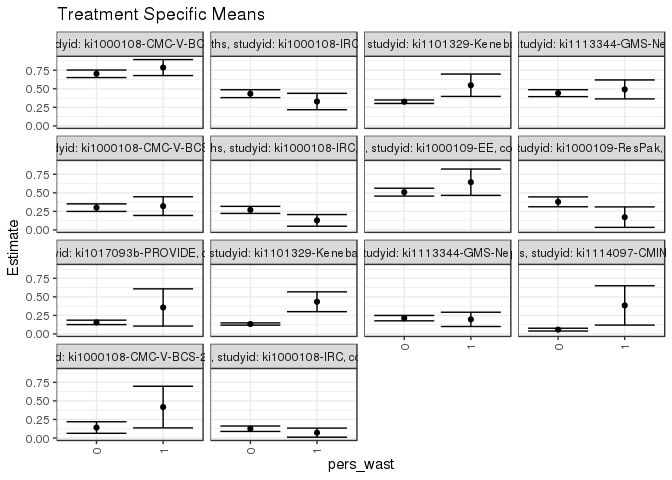

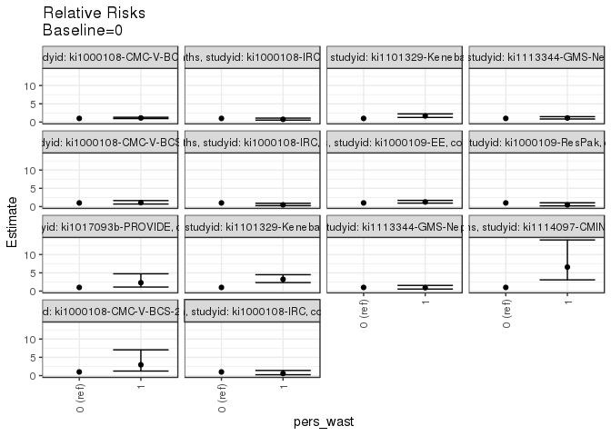

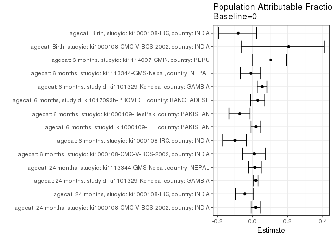

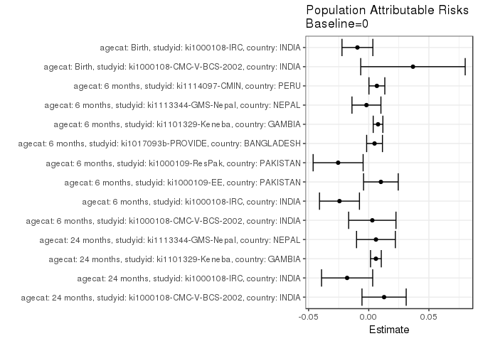

## Results Table

### Parameter: TSM

| agecat | studyid | country | intervention_level | baseline_level | estimate | ci_lower | ci_upper |
| --- | --- | --- | --- | --- | --- | --- | --- |
| Birth | ki1000108-CMC-V-BCS-2002 | INDIA | 0 | NA | 0.1410256 | 0.0633533 | 0.2186979 |
| Birth | ki1000108-CMC-V-BCS-2002 | INDIA | 1 | NA | 0.4166667 | 0.1361643 | 0.6971690 |
| Birth | ki1000108-IRC | INDIA | 0 | NA | 0.1253918 | 0.0890042 | 0.1617795 |
| Birth | ki1000108-IRC | INDIA | 1 | NA | 0.0724638 | 0.0112132 | 0.1337143 |
| 6 months | ki1000108-CMC-V-BCS-2002 | INDIA | 0 | NA | 0.3003195 | 0.2494671 | 0.3511719 |
| 6 months | ki1000108-CMC-V-BCS-2002 | INDIA | 1 | NA | 0.3207547 | 0.1949189 | 0.4465905 |
| 6 months | ki1000108-IRC | INDIA | 0 | NA | 0.2700297 | 0.2225699 | 0.3174894 |
| 6 months | ki1000108-IRC | INDIA | 1 | NA | 0.1285714 | 0.0500621 | 0.2070808 |
| 6 months | ki1000109-EE | PAKISTAN | 0 | NA | 0.5087209 | 0.4558207 | 0.5616211 |
| 6 months | ki1000109-EE | PAKISTAN | 1 | NA | 0.6428571 | 0.4651390 | 0.8205753 |
| 6 months | ki1000109-ResPak | PAKISTAN | 0 | NA | 0.3786408 | 0.3122626 | 0.4450190 |
| 6 months | ki1000109-ResPak | PAKISTAN | 1 | NA | 0.1724138 | 0.0346396 | 0.3101879 |
| 6 months | ki1017093b-PROVIDE | BANGLADESH | 0 | NA | 0.1564148 | 0.1265425 | 0.1862870 |
| 6 months | ki1017093b-PROVIDE | BANGLADESH | 1 | NA | 0.3571429 | 0.1059339 | 0.6083518 |
| 6 months | ki1101329-Keneba | GAMBIA | 0 | NA | 0.1342315 | 0.1193025 | 0.1491606 |
| 6 months | ki1101329-Keneba | GAMBIA | 1 | NA | 0.4339623 | 0.3004982 | 0.5674264 |
| 6 months | ki1113344-GMS-Nepal | NEPAL | 0 | NA | 0.2132797 | 0.1772350 | 0.2493243 |
| 6 months | ki1113344-GMS-Nepal | NEPAL | 1 | NA | 0.1969697 | 0.1009351 | 0.2930043 |
| 6 months | ki1114097-CMIN | PERU | 0 | NA | 0.0586319 | 0.0400343 | 0.0772295 |
| 6 months | ki1114097-CMIN | PERU | 1 | NA | 0.3846154 | 0.1199424 | 0.6492884 |
| 24 months | ki1000108-CMC-V-BCS-2002 | INDIA | 0 | NA | 0.7019231 | 0.6510989 | 0.7527473 |
| 24 months | ki1000108-CMC-V-BCS-2002 | INDIA | 1 | NA | 0.7857143 | 0.6780990 | 0.8933296 |
| 24 months | ki1000108-IRC | INDIA | 0 | NA | 0.4336283 | 0.3808094 | 0.4864472 |
| 24 months | ki1000108-IRC | INDIA | 1 | NA | 0.3285714 | 0.2184060 | 0.4387369 |
| 24 months | ki1101329-Keneba | GAMBIA | 0 | NA | 0.3258870 | 0.3023322 | 0.3494418 |
| 24 months | ki1101329-Keneba | GAMBIA | 1 | NA | 0.5476190 | 0.3970437 | 0.6981944 |
| 24 months | ki1113344-GMS-Nepal | NEPAL | 0 | NA | 0.4409091 | 0.3944711 | 0.4873470 |
| 24 months | ki1113344-GMS-Nepal | NEPAL | 1 | NA | 0.4915254 | 0.3638329 | 0.6192179 |

### Parameter: E(Y)

| agecat | studyid | country | intervention_level | baseline_level | estimate | ci_lower | ci_upper |
| --- | --- | --- | --- | --- | --- | --- | --- |
| Birth | ki1000108-CMC-V-BCS-2002 | INDIA | NA | NA | 0.1777778 | 0.0983474 | 0.2572081 |
| Birth | ki1000108-IRC | INDIA | NA | NA | 0.1159794 | 0.0840777 | 0.1478811 |
| 6 months | ki1000108-CMC-V-BCS-2002 | INDIA | NA | NA | 0.3032787 | 0.2561210 | 0.3504363 |
| 6 months | ki1000108-IRC | INDIA | NA | NA | 0.2457002 | 0.2038248 | 0.2875757 |
| 6 months | ki1000109-EE | PAKISTAN | NA | NA | 0.5188172 | 0.4679751 | 0.5696593 |
| 6 months | ki1000109-ResPak | PAKISTAN | NA | NA | 0.3531915 | 0.2919518 | 0.4144312 |
| 6 months | ki1017093b-PROVIDE | BANGLADESH | NA | NA | 0.1612350 | 0.1313580 | 0.1911120 |
| 6 months | ki1101329-Keneba | GAMBIA | NA | NA | 0.1419543 | 0.1268686 | 0.1570400 |
| 6 months | ki1113344-GMS-Nepal | NEPAL | NA | NA | 0.2113677 | 0.1776128 | 0.2451225 |
| 6 months | ki1114097-CMIN | PERU | NA | NA | 0.0653907 | 0.0460250 | 0.0847565 |
| 24 months | ki1000108-CMC-V-BCS-2002 | INDIA | NA | NA | 0.7146739 | 0.6684741 | 0.7608737 |
| 24 months | ki1000108-IRC | INDIA | NA | NA | 0.4156479 | 0.3678270 | 0.4634689 |
| 24 months | ki1101329-Keneba | GAMBIA | NA | NA | 0.3318414 | 0.3084975 | 0.3551853 |
| 24 months | ki1113344-GMS-Nepal | NEPAL | NA | NA | 0.4468938 | 0.4032281 | 0.4905594 |

### Parameter: RR

| agecat | studyid | country | intervention_level | baseline_level | estimate | ci_lower | ci_upper |
| --- | --- | --- | --- | --- | --- | --- | --- |
| Birth | ki1000108-CMC-V-BCS-2002 | INDIA | 0 | 0 | 1.0000000 | 1.0000000 | 1.000000 |
| Birth | ki1000108-CMC-V-BCS-2002 | INDIA | 1 | 0 | 2.9545455 | 1.2380602 | 7.050820 |
| Birth | ki1000108-IRC | INDIA | 0 | 0 | 1.0000000 | 1.0000000 | 1.000000 |
| Birth | ki1000108-IRC | INDIA | 1 | 0 | 0.5778986 | 0.2364447 | 1.412452 |
| 6 months | ki1000108-CMC-V-BCS-2002 | INDIA | 0 | 0 | 1.0000000 | 1.0000000 | 1.000000 |
| 6 months | ki1000108-CMC-V-BCS-2002 | INDIA | 1 | 0 | 1.0680450 | 0.6966555 | 1.637423 |
| 6 months | ki1000108-IRC | INDIA | 0 | 0 | 1.0000000 | 1.0000000 | 1.000000 |
| 6 months | ki1000108-IRC | INDIA | 1 | 0 | 0.4761381 | 0.2522167 | 0.898860 |
| 6 months | ki1000109-EE | PAKISTAN | 0 | 0 | 1.0000000 | 1.0000000 | 1.000000 |
| 6 months | ki1000109-EE | PAKISTAN | 1 | 0 | 1.2636735 | 0.9405053 | 1.697886 |
| 6 months | ki1000109-ResPak | PAKISTAN | 0 | 0 | 1.0000000 | 1.0000000 | 1.000000 |
| 6 months | ki1000109-ResPak | PAKISTAN | 1 | 0 | 0.4553492 | 0.2009329 | 1.031901 |
| 6 months | ki1017093b-PROVIDE | BANGLADESH | 0 | 0 | 1.0000000 | 1.0000000 | 1.000000 |
| 6 months | ki1017093b-PROVIDE | BANGLADESH | 1 | 0 | 2.2833066 | 1.1016106 | 4.732606 |
| 6 months | ki1101329-Keneba | GAMBIA | 0 | 0 | 1.0000000 | 1.0000000 | 1.000000 |
| 6 months | ki1101329-Keneba | GAMBIA | 1 | 0 | 3.2329382 | 2.3311258 | 4.483623 |
| 6 months | ki1113344-GMS-Nepal | NEPAL | 0 | 0 | 1.0000000 | 1.0000000 | 1.000000 |
| 6 months | ki1113344-GMS-Nepal | NEPAL | 1 | 0 | 0.9235277 | 0.5512457 | 1.547229 |
| 6 months | ki1114097-CMIN | PERU | 0 | 0 | 1.0000000 | 1.0000000 | 1.000000 |
| 6 months | ki1114097-CMIN | PERU | 1 | 0 | 6.5598291 | 3.0747702 | 13.994983 |
| 24 months | ki1000108-CMC-V-BCS-2002 | INDIA | 0 | 0 | 1.0000000 | 1.0000000 | 1.000000 |
| 24 months | ki1000108-CMC-V-BCS-2002 | INDIA | 1 | 0 | 1.1193738 | 0.9587193 | 1.306949 |
| 24 months | ki1000108-IRC | INDIA | 0 | 0 | 1.0000000 | 1.0000000 | 1.000000 |
| 24 months | ki1000108-IRC | INDIA | 1 | 0 | 0.7577259 | 0.5303809 | 1.082521 |
| 24 months | ki1101329-Keneba | GAMBIA | 0 | 0 | 1.0000000 | 1.0000000 | 1.000000 |
| 24 months | ki1101329-Keneba | GAMBIA | 1 | 0 | 1.6803955 | 1.2645602 | 2.232973 |
| 24 months | ki1113344-GMS-Nepal | NEPAL | 0 | 0 | 1.0000000 | 1.0000000 | 1.000000 |
| 24 months | ki1113344-GMS-Nepal | NEPAL | 1 | 0 | 1.1147999 | 0.8422728 | 1.475506 |

### Parameter: PAR

| agecat | studyid | country | intervention_level | baseline_level | estimate | ci_lower | ci_upper |
| --- | --- | --- | --- | --- | --- | --- | --- |
| Birth | ki1000108-CMC-V-BCS-2002 | INDIA | 0 | NA | 0.0367521 | -0.0066643 | 0.0801686 |
| Birth | ki1000108-IRC | INDIA | 0 | NA | -0.0094125 | -0.0222416 | 0.0034166 |
| 6 months | ki1000108-CMC-V-BCS-2002 | INDIA | 0 | NA | 0.0029592 | -0.0167085 | 0.0226269 |
| 6 months | ki1000108-IRC | INDIA | 0 | NA | -0.0243294 | -0.0409402 | -0.0077187 |
| 6 months | ki1000109-EE | PAKISTAN | 0 | NA | 0.0100963 | -0.0043175 | 0.0245100 |
| 6 months | ki1000109-ResPak | PAKISTAN | 0 | NA | -0.0254493 | -0.0462264 | -0.0046721 |
| 6 months | ki1017093b-PROVIDE | BANGLADESH | 0 | NA | 0.0048202 | -0.0017477 | 0.0113882 |
| 6 months | ki1101329-Keneba | GAMBIA | 0 | NA | 0.0077228 | 0.0036995 | 0.0117460 |
| 6 months | ki1113344-GMS-Nepal | NEPAL | 0 | NA | -0.0019120 | -0.0139447 | 0.0101207 |
| 6 months | ki1114097-CMIN | PERU | 0 | NA | 0.0067588 | 0.0001632 | 0.0133545 |
| 24 months | ki1000108-CMC-V-BCS-2002 | INDIA | 0 | NA | 0.0127508 | -0.0056198 | 0.0311214 |
| 24 months | ki1000108-IRC | INDIA | 0 | NA | -0.0179804 | -0.0392398 | 0.0032790 |
| 24 months | ki1101329-Keneba | GAMBIA | 0 | NA | 0.0059544 | 0.0014926 | 0.0104163 |
| 24 months | ki1113344-GMS-Nepal | NEPAL | 0 | NA | 0.0059847 | -0.0101446 | 0.0221140 |

### Parameter: PAF

| agecat | studyid | country | intervention_level | baseline_level | estimate | ci_lower | ci_upper |
| --- | --- | --- | --- | --- | --- | --- | --- |
| Birth | ki1000108-CMC-V-BCS-2002 | INDIA | 0 | NA | 0.2067308 | -0.0633741 | 0.4082270 |
| Birth | ki1000108-IRC | INDIA | 0 | NA | -0.0811564 | -0.1958293 | 0.0225200 |
| 6 months | ki1000108-CMC-V-BCS-2002 | INDIA | 0 | NA | 0.0097574 | -0.0572607 | 0.0725273 |
| 6 months | ki1000108-IRC | INDIA | 0 | NA | -0.0990208 | -0.1681104 | -0.0340176 |
| 6 months | ki1000109-EE | PAKISTAN | 0 | NA | 0.0194602 | -0.0087940 | 0.0469230 |
| 6 months | ki1000109-ResPak | PAKISTAN | 0 | NA | -0.0720552 | -0.1327650 | -0.0145991 |
| 6 months | ki1017093b-PROVIDE | BANGLADESH | 0 | NA | 0.0298957 | -0.0114600 | 0.0695604 |
| 6 months | ki1101329-Keneba | GAMBIA | 0 | NA | 0.0544032 | 0.0260526 | 0.0819285 |
| 6 months | ki1113344-GMS-Nepal | NEPAL | 0 | NA | -0.0090459 | -0.0676014 | 0.0462981 |
| 6 months | ki1114097-CMIN | PERU | 0 | NA | 0.1033606 | 0.0012333 | 0.1950450 |
| 24 months | ki1000108-CMC-V-BCS-2002 | INDIA | 0 | NA | 0.0178415 | -0.0083067 | 0.0433115 |
| 24 months | ki1000108-IRC | INDIA | 0 | NA | -0.0432587 | -0.0958039 | 0.0067668 |
| 24 months | ki1101329-Keneba | GAMBIA | 0 | NA | 0.0179436 | 0.0044068 | 0.0312964 |
| 24 months | ki1113344-GMS-Nepal | NEPAL | 0 | NA | 0.0133918 | -0.0233832 | 0.0488452 |